# HW7

Svartha

November 9, 2016

```r
library(highcharter)
library(dplyr)
library(mosaic)
library(magrittr)
library(readxl)
library(psych)
library(tidyr)
```

```r
#reading the data
data <- read.csv("data/sp500hst.txt", header=FALSE)
names(data)<-c("day","symbol","open","high","low","close","volume")

cf<-read.csv("data/constituents-financials.csv")

cf %>% select(symbol = Symbol,Name,Sector)->names
data <- merge(names,data)

sp <-read_excel("data/SP500index.xls")
sp$DATE=as.character(sp$DATE)
```

**First two questions are not answered in order**

## Buying Stock on Mondays

We have to add a column to the data indicating the weekday.

```r
data %>% mutate(avrg = round((open+close+high+low)/4,2)) ->data

data %>%
  mutate(y = round(day/10000)) %>%
  mutate(m = round((day-10000*y)/100)) %>%
  mutate(d = day-10000*y-100*m) %>%
  mutate(DATE = ifelse(m<10, ifelse(d<10, paste0(y,'-0',m,'-0',d), paste0(y,'-0',m,'-',d)),
                       ifelse(d<10, paste0(y,'-',m,'-0',d),paste0(y,'-',m,'-',d))))%>%
  mutate(weekday = weekdays(as.Date(DATE)))->data
```

Now lets run an ANOVA test to see if these days have any significant differenc.

**$H_0$ : All the Weekdays are similar** **$H_1$ : Some days, the stock price of companies is higher than other days**

```r
days <- aov(data$avrg~factor(data$weekday))
summary(days)
```

```
##                         Df    Sum Sq Mean Sq F value Pr(>F)
## factor(data$weekday)     4      2533   633.2   0.345  0.847
## Residuals            91092 167005041  1833.4
```

Thus, There’s no significant difference between the average stock prices in different days of the week.

```r
highchart() %>%
  hc_add_series_boxplot(data$avrg,by = data$weekday , name = "Stock Price") %>%
  hc_add_theme(hc_theme_538()) %>%
  hc_title(text = "Comparision of stock price distribution within weekdays")
```

[interactive chart not shown]

## Most Efficient Company

I define Efficiency such that:

$$\eta=(P_j-P_i)/P_i$$

$$Where: \quad P_i = \quad Average \quad Stock \quad Price \quad Of \quad the \quad Company \quad at \quad month \quad i$$

Let i=earliest month in owr data, and j=latest month. thus:

```r
data %>% group_by(m,y,symbol) %>%
  filter(m==8, y %in%c(2010,2009)) %>%
  group_by(y,Name) %>%
  summarise(avrg=round(mean(avrg),2)) %>%
  spread(y,avrg) ->effic
names(effic)=c("Name","First","Last")

effic %>% mutate(eta = round(Last/First-1,2) , delta = Last-First)->effic
```

The companies with the highest progress percentage:

```r
effic = effic[order(desc(effic$eta)),]
knitr::kable(effic[1:10,c(1,4)])
```

| Name | eta |
| --- | --- |
| E*Trade | 8.81 |
| Akamai Technologies Inc | 1.31 |
| Pioneer Natural Resources | 0.95 |
| Salesforce.com | 0.92 |
| NetApp | 0.87 |
| Cummins Inc. | 0.72 |
| Apartment Investment & Mgmt | 0.71 |
| Cognizant Technology Solutions | 0.70 |
| Estee Lauder Cos. | 0.69 |
| Equity Residential | 0.66 |

The companies with the highest pure increase in stock price

```r
effic = effic[order(desc(effic$delta)),]
knitr::kable(effic[1:10,c(1,5)])
```

| Name | delta |
| --- | --- |
| Intuitive Surgical Inc. | 94.31 |
| Apple Inc. | 86.40 |
| AutoZone Inc | 57.77 |
| Salesforce.com | 48.09 |
| Amazon.com Inc | 42.50 |
| AvalonBay Communities, Inc. | 38.45 |
| Cummins Inc. | 33.59 |
| Wynn Resorts Ltd | 32.79 |
| Public Storage | 28.95 |
| Pioneer Natural Resources | 28.65 |

overall progress:

```r
highchart() %>%
  hc_add_series_boxplot(effic$eta,name = "Efficiency Rate") %>%
  hc_add_series_boxplot(effic$delta, name = " Pure Stock Price Change") %>%
  hc_title(text = "Distribution of change within all of the companies") %>%
  hc_add_theme(hc_theme_538())
```

[interactive chart not shown]

## Companies with The Highest Number of Transactions

```r
cf %>% select(symbol = Symbol,Name,Sector)->names
data <- merge(names,data)

data %>% group_by(symbol) %>% summarise(meanval = round(mean(volume)))-> compval
compval <- compval[order(desc(compval$meanval)),]
compval <- compval[1:10,]
highchart() %>%
  hc_add_series_boxplot(filter(data,symbol %in% compval$symbol)$volume,
                        by = filter(data,symbol %in% compval$symbol)$Name,
                        group = filter(data,symbol %in% compval$symbol)$Sector,
                        name = "Distribution of The Volume of Transactions",
                        colorByPoint = T) %>%
  hc_add_theme(hc_theme_538()) %>%
  hc_title(text = "Comparision of Volume of Transactions Amongst Corporations")
```

[interactive chart not shown]

As we can see, the following are the top 10 companies with the highest transaction rates:

```r
compval<-merge(names,compval,all.y=T)
knitr::kable(compval[,c(2,3,4)])
```

| Name | Sector | meanval |
| --- | --- | --- |
| Bank of America Corp | Financials | 1901280 |
| Citigroup Inc. | Financials | 5952378 |
| Cisco Systems | Information Technology | 503858 |
| E*Trade | Financials | 558954 |
| Ford Motor | Consumer Discretionary | 939643 |
| General Electric | Industrials | 834500 |
| Intel Corp. | Information Technology | 663817 |
| Microsoft Corp. | Information Technology | 612659 |
| Pfizer Inc. | Health Care | 579151 |
| Wells Fargo | Financials | 448944 |

## Principal Indexes For The stock market

The market value should be proportional to amount of money transferred in the market per day. thus, the average price of each corporation’s stock, multiplied by the number of transactions should give a good estimation of the market value.

```r
#creating the index
data %>% filter(!is.na(open)) %>% mutate(index = round(volume*avrg))->data

#preparing the vectors for applying pca
reshape2::dcast(day~symbol,data=data,value.var=c("index"))->matr
matr = matr[,-1]
matr[is.na(matr)]=0

#calculating pca
pca.mat=prcomp(matr)
summary(pca.mat)$importance[3,1:20]
```

```
##     PC1     PC2     PC3     PC4     PC5     PC6     PC7     PC8     PC9
## 0.34069 0.51036 0.59409 0.65189 0.70126 0.73486 0.75830 0.77970 0.79730
##    PC10    PC11    PC12    PC13    PC14    PC15    PC16    PC17    PC18
## 0.81350 0.82732 0.83910 0.85046 0.86116 0.86990 0.87837 0.88573 0.89220
##    PC19    PC20
## 0.89833 0.90393
```

Let’s see how well these components describe the variance:

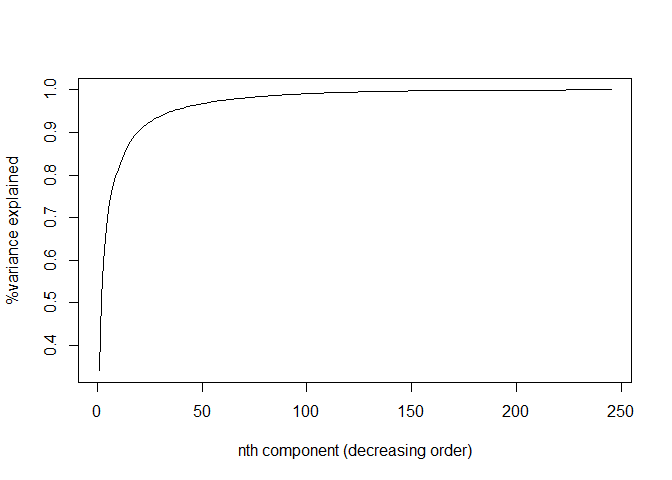

```r
plot(summary(pca.mat)$importance[3,], type="l",
     ylab="%variance explained", xlab="nth component (decreasing order)")
```

we’ll keep the first 5 components.

```r
chosen.components = 1:5
feature.vector = pca.mat$rotation[,chosen.components]
feature.vector[1:10,1:5]
```

```
##               PC1           PC2           PC3           PC4          PC5
## A    -0.006447245  0.0021640098  0.0042609848 -0.0015763934  0.004248022
## AA   -0.020665221  0.0195873936 -0.0275960502  0.0209676136  0.029817289
## AAPL -0.664428531 -0.6422238260  0.0383185854 -0.1999772216 -0.279232111
## ABC  -0.007488934 -0.0071479776 -0.0012279145  0.0069896167  0.012087497
## ABT  -0.017930846  0.0040150789  0.0131195441  0.0082456549  0.022917364
## ADBE -0.014413646  0.0014109813  0.0109025184  0.0067641381  0.024236579
## ADI  -0.007429000  0.0021028282 -0.0005840631 -0.0027290248  0.005576476
## ADM  -0.005381173  0.0007897074 -0.0003231858  0.0053050164  0.010534037
## ADP  -0.007544477  0.0008823104 -0.0026856600 -0.0041540924  0.009459968
## ADSK -0.007703174 -0.0039887015 -0.0019382306 -0.0009866483  0.008653037
```

Finding out the most influencial companies in determining our new components:

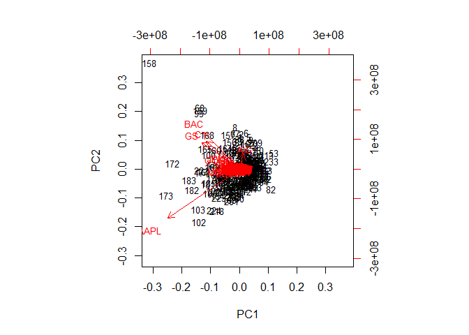

```r
biplot(pca.mat,cex=0.8)
```

Now we’ll create the index for each day.

```r
data %>% group_by(DATE) %>% summarise(count = n())->dates
indexes = as.matrix(matr) %*% feature.vector
sp1  = cbind(DATE = dates$DATE,data.frame(indexes))
```

visualizing these indexes:

```r
highchart() %>%
  hc_add_series_ts(as.ts(sp1$PC1),name = "PC1") %>%
  hc_add_series_ts(as.ts(sp1$PC2),name = "PC2") %>%
  hc_add_series_ts(as.ts(sp1$PC3),name = "PC3") %>%
  hc_add_series_ts(as.ts(sp1$PC4),name = "PC4") %>%
  hc_add_series_ts(as.ts(sp1$PC5),name = "PC5") %>%
  hc_add_theme(hc_theme_538()) %>%
  hc_title(text = "Changes of the 5 principal indexes over one year's time")
```

[interactive chart not shown]

## Comparing with S&P Index

first, we merge the data:

```r
spdata<-merge(sp1,sp,all.x=T)
spdata$VALUE = as.integer(spdata$VALUE)
```

now we normalize these indexes and compare their change over time.

```r
spdata$VALUE = round(scale(spdata$VALUE),4)
spdata$PC1 = round(scale(spdata$PC1),4)
spdata$PC2 = round(scale(spdata$PC2),4)
spdata$PC3 = round(scale(spdata$PC3),4)
spdata$PC4 = round(scale(spdata$PC4),4)
spdata$PC5 = round(scale(spdata$PC5),4)
highchart() %>%
  hc_add_series_ts(as.ts(spdata$PC1),name = "PC1") %>%
  hc_add_series_ts(as.ts(spdata$PC2),name = "PC2") %>%
  hc_add_series_ts(as.ts(spdata$PC3),name = "PC3") %>%
  hc_add_series_ts(as.ts(spdata$PC4),name = "PC4") %>%
  hc_add_series_ts(as.ts(spdata$PC5),name = "PC5") %>%
  hc_add_series_ts(as.ts(spdata$VALUE), name = "S&P") %>%
  hc_add_theme(hc_theme_economist()) %>%
  hc_title(text = "Changes of the s&p and our indexes over one year's time")
```

[interactive chart not shown]

we can see that our indexes combined together can explain the s&p factor in most of the points.

## Factor Analysis: Finding Hidden Factors of The Market

### Finding the number of influential factors:

```r
data <- read.csv("data/sp500hst.txt", header=FALSE,stringsAsFactors = T)
names(data)<-c("day","symbol","open","high","low","close","volume")
data$symbol=as.integer(data$symbol)
data %>% select(symbol,open,high,low,close,volume)->data

parallel = fa.parallel(data, fm="ml",fa="fa")
```

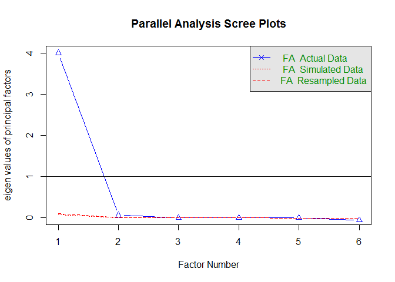

```
## Parallel analysis suggests that the number of factors =  2  and the number of components =  NA
```

There are 2 indexes or factors in this data, so there’s one hidden factor besides s&p index.

### Creating the model

```r
famodel = factanal(data, factors = 2, method ="mle",scores = "regression")
print(famodel)
```

```
##
## Call:
## factanal(x = data, factors = 2, scores = "regression", method = "mle")
##
## Uniquenesses:
## symbol   open   high    low  close volume
##  0.937  0.005  0.005  0.005  0.005  0.929
##
## Loadings:
##        Factor1 Factor2
## symbol          0.245
## open    0.999
## high    0.999
## low     0.999
## close   0.999
## volume         -0.253
##
##                Factor1 Factor2
## SS loadings      4.002   0.127
## Proportion Var   0.667   0.021
## Cumulative Var   0.667   0.688
##
## Test of the hypothesis that 2 factors are sufficient.
## The chi square statistic is 937909.6 on 4 degrees of freedom.
## The p-value is 0
```

### Finding the loadings and important companies

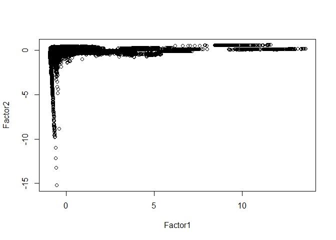

```r
score = famodel$scores
plot(score[,1:2])
```